# R Notebook

# Problem Set 5

# Problem 5.2

```r
library(tidyverse)
library(stargazer)
library(rpart)
library(rpart.plot)

#read the data
health_raw <- read_csv("health.csv")
#present first 6 rows of health data
health_raw %>% head()
```

| ltotexp | suppins | income | educyr | age | famsze | totchr | female | white | hisp | marry | northe | mwest | south | msa | phylim | actlim | injury | priolist | hvgg |
| --- | --- | --- | --- | --- | --- | --- | --- | --- | --- | --- | --- | --- | --- | --- | --- | --- | --- | --- | --- |
| 9.655731 | 0 | 7.266 | 12 | 84 | 2 | 1 | 1 | 1 | 0 | 1 | 0 | 1 | 0 | 1 | 1 | 1 | 0 | 1 | 1 |
| 9.167120 | 0 | 17.000 | 16 | 80 | 2 | 3 | 0 | 0 | 0 | 1 | 1 | 0 | 0 | 1 | 0 | 0 | 0 | 0 | 1 |
| 7.779885 | 0 | 126.317 | 17 | 78 | 2 | 1 | 0 | 1 | 1 | 1 | 0 | 0 | 1 | 1 | 0 | 0 | 0 | 1 | 0 |
| 7.681099 | 0 | 33.501 | 11 | 79 | 1 | 2 | 1 | 1 | 0 | 0 | 0 | 0 | 1 | 0 | 0 | 0 | 0 | 1 | 1 |
| 7.863651 | 1 | 57.869 | 17 | 70 | 2 | 1 | 0 | 1 | 0 | 1 | 1 | 0 | 0 | 1 | 0 | 0 | 0 | 1 | 0 |
| 7.109062 | 0 | 23.268 | 12 | 76 | 3 | 3 | 1 | 1 | 0 | 1 | 0 | 0 | 0 | 1 | 1 | 1 | 0 | 1 | 1 |

```r
dummies <- c("suppins", "female","white", "hisp",  "marry", "northe" ,
              "mwest", "south", "msa","phylim","actlim","injury","priolist", "hvgg")


health <- na.omit(health_raw)
health[, dummies] <- lapply(health[,dummies], factor)
```

**a) Generate an enlarged regressor set, containing the original varibles in $x_{i}$ and • all interaction terms and • the squared terms of the continuous variables of $x_{i}$.**

**Explain, why adding squared terms of the dummy variables does not make sense**

- It does not make sense because 1 x 1 = 1 and 0 x 0 = 0, such that squared dummies are the same as the dummies

```r
# function to add interaction term between all variables of a df except the dep_var
add_inter_terms <- function(df, dep_var, dummies = NULL){
  vars <- colnames(df)[! colnames(df) %in% dep_var]
  for (i in vars) {
    for (j in vars) {
      if (i < j ) {
        df[paste0(i, "X", j)] <- df[i] * df[j]
        if (i %in% dummies && j %in% dummies) {
          df[[paste0(i, "X", j)]] <- factor(df[[paste0(i, "X", j)]])
        }
      }
    }
  }
  df
}

# function to add squared terms to df for specified vars
add_squared_terms <- function(df, vars) {
  for (i in vars) {
    df[paste0(i, "X", i)] <- df[i] * df[i]
  }
  df
}

# variables to be squared
continuous_vars <- c("income", "educyr", "age", "famsze", "totchr")

# extend dataframe
health_extend <- add_inter_terms(health_raw, c("ltotexp", "suppins"), dummies = dummies)
health_extend <- add_squared_terms(health_extend, continuous_vars)
health_extend[,dummies] <- lapply(health_extend[,dummies], factor)
health_extend <- na.omit(health_extend)
# interactions between regional dummies don't not make sense
health_extend <- health_extend[, !(names(health_extend) %in% c("mwestXnorthe", "mwestXsouth",
                                                                    "northeXsouth"))]
```

**b) Denote the vector of extended explanatory varibles by $x_{e,i}$. Standardize the regressors in $x_{i}$ and $x_{e,i}$, respectively.**

```r
health[, continuous_vars] <- scale(health[, continuous_vars])

health %>% head()
```

| ltotexp | suppins | income | educyr | age | famsze | totchr | female | white | hisp | marry | northe | mwest | south | msa | phylim | actlim | injury | priolist | hvgg |
| --- | --- | --- | --- | --- | --- | --- | --- | --- | --- | --- | --- | --- | --- | --- | --- | --- | --- | --- | --- |
| 9.655731 | 0 | -0.68189339 | 0.0504867 | 1.5299077 | 0.1133355 | -0.6247416 | 1 | 1 | 0 | 1 | 0 | 1 | 0 | 1 | 1 | 1 | 0 | 1 | 1 |
| 9.167120 | 0 | -0.25137361 | 1.2251968 | 0.9025527 | 0.1133355 | 0.9201216 | 0 | 0 | 0 | 1 | 1 | 0 | 0 | 1 | 0 | 0 | 0 | 0 | 1 |
| 7.779885 | 0 | 4.58354837 | 1.5188743 | 0.5888752 | 0.1133355 | -0.6247416 | 0 | 1 | 1 | 1 | 0 | 0 | 1 | 1 | 0 | 0 | 0 | 1 | 0 |
| 7.681099 | 0 | 0.47844012 | -0.2431908 | 0.7457139 | -0.9235267 | 0.1476900 | 1 | 1 | 0 | 0 | 0 | 0 | 1 | 0 | 0 | 0 | 0 | 1 | 1 |
| 7.863651 | 1 | 1.55619910 | 1.5188743 | -0.6658350 | 0.1133355 | -0.6247416 | 0 | 1 | 0 | 1 | 1 | 0 | 0 | 1 | 0 | 0 | 0 | 1 | 0 |
| 7.109062 | 0 | 0.02585034 | 0.0504867 | 0.2751976 | 1.1501978 | 0.9201216 | 1 | 1 | 0 | 1 | 0 | 0 | 0 | 1 | 1 | 1 | 0 | 1 | 1 |

```r
scale_all_but <- function(df, but) {
  for (var in colnames(df)[! colnames(df) %in% but]){
    if (class(df[[var]]) == "numeric") {
      df[var] <- scale(df[var])
    }

  }
  df
}

health_extend <- scale_all_but(health_extend, c("ltotexp", "suppins"))
health <- scale_all_but(health, c("ltotexp", "suppins"))
health_extend %>% head()
```

| ltotexp | suppins | income | educyr | age | famsze | totchr | female | white | hisp | marry | northe | mwest | south | msa | phylim | actlim | injury | priolist | hvgg | incomeXtotchr | incomeXwhite | incomeXmarry | incomeXnorthe | incomeXmwest | incomeXsouth | incomeXmsa | incomeXphylim | incomeXinjury | incomeXpriolist | … |
| --- | --- | --- | --- | --- | --- | --- | --- | --- | --- | --- | --- | --- | --- | --- | --- | --- | --- | --- | --- | --- | --- | --- | --- | --- | --- | --- | --- | --- | --- | --- |
| 9.655731 | 0 | -0.68189339 | 0.0504867 | 1.5299077 | 0.1133355 | -0.6247416 | 1 | 1 | 0 | 1 | 0 | 1 | 0 | 1 | 1 | 1 | 0 | 1 | 1 | -0.6531459 | -0.65308065 | -0.2721549 | -0.2788725 | 0.2177053 | -0.5000242 | -0.44404035 | -0.08493977 | -0.3508294 | -0.5223255 | … |
| 9.167120 | 0 | -0.25137361 | 1.2251968 | 0.9025527 | 0.1133355 | 0.9201216 | 0 | 0 | 0 | 1 | 1 | 0 | 0 | 1 | 0 | 0 | 0 | 0 | 1 | 0.2572083 | -0.97484512 | 0.1927706 | 0.9977376 | -0.3788463 | -0.5000242 | -0.02551304 | -0.54255728 | -0.3508294 | -0.8642796 | … |
| 7.779885 | 0 | 4.58354837 | 1.5188743 | 0.5888752 | 0.1133355 | -0.6247416 | 0 | 1 | 1 | 1 | 0 | 0 | 1 | 1 | 0 | 0 | 0 | 1 | 0 | 1.8249850 | 4.61892341 | 5.4140835 | -0.2788725 | -0.3788463 | 6.8545851 | 4.67472836 | -0.54255728 | -0.3508294 | 5.0804791 | … |
| 7.681099 | 0 | 0.47844012 | -0.2431908 | 0.7457139 | -0.9235267 | 0.1476900 | 1 | 1 | 0 | 0 | 0 | 0 | 1 | 0 | 0 | 0 | 0 | 1 | 1 | 0.5903012 | 0.50869898 | -0.6192012 | -0.2788725 | -0.3788463 | 1.4505190 | -0.75645245 | -0.54255728 | -0.3508294 | 0.7123519 | … |
| 7.863651 | 1 | 1.55619910 | 1.5188743 | -0.6658350 | 0.1133355 | -0.6247416 | 0 | 1 | 0 | 1 | 1 | 0 | 0 | 1 | 0 | 0 | 0 | 1 | 0 | 0.4001914 | 1.58780117 | 2.1447985 | 4.0667832 | -0.3788463 | -0.5000242 | 1.73170831 | -0.54255728 | -0.3508294 | 1.8591641 | … |
| 7.109062 | 0 | 0.02585034 | 0.0504867 | 0.2751976 | 1.1501978 | 0.9201216 | 1 | 1 | 0 | 1 | 0 | 0 | 0 | 1 | 1 | 1 | 0 | 1 | 1 | 0.6486269 | 0.05554514 | 0.4921493 | -0.2788725 | -0.3788463 | -0.5000242 | 0.24398862 | 0.92287682 | -0.3508294 | 0.2307642 | … |

**c) As naive approach to estimate the ATE, estimate model 1 by OLS, using $g(x) = x_{i}′β$. Also obtain the 95% confidence bounds.**

```r
OLS <- lm(ltotexp ~ ., data = health)
stargazer(OLS, type = "text", keep = "suppins1", ci = TRUE,
          omit.stat = "all")
```

```
====================================
             Dependent variable:
         ---------------------------
                   ltotexp
------------------------------------
suppins1          0.171***
               (0.079, 0.262)

====================================
====================================
Note:    *p<0.1; **p<0.05; ***p<0.01
```

**d) Comment on potential problems with the naive approach.**

It is very unlikely that the Unconfoundedness assumption holds, which in turn does not allow to indentify the ATE. Further, the functional form might be misspecified because interaction terms and non-linear effects are not included in the regression.

### Lassoing

**e) Estimate f1 and f2 using the LASSO framework and the extended regressors $x_{e,i}$. Use 5-fold cross-validation to tune the penalty parameter.**

```r
# install.packages("glmnet")
library(glmnet)
set.seed(1887)
# dataframes as matrices (throw out NAs)
x <- data.matrix((health_extend[complete.cases(health_extend), ! names(health_extend) %in% c("ltotexp", "suppins")]))
ltotexp <- data.matrix(health_extend[complete.cases(health_extend), "ltotexp"])
suppins <- data.matrix(health_extend[complete.cases(health_extend), "suppins"]) - 1

# find best lambdas
lambdas <- 10^seq(2, -3, by = -.1)

cv_f1 <- cv.glmnet(x = x, y = ltotexp, alpha  = 1, nfolds = 5, standardize = F)
best_lambda_f1 <- cv_f1$lambda.min
best_lambda_f1
```

```
[1] 0.006733688
```

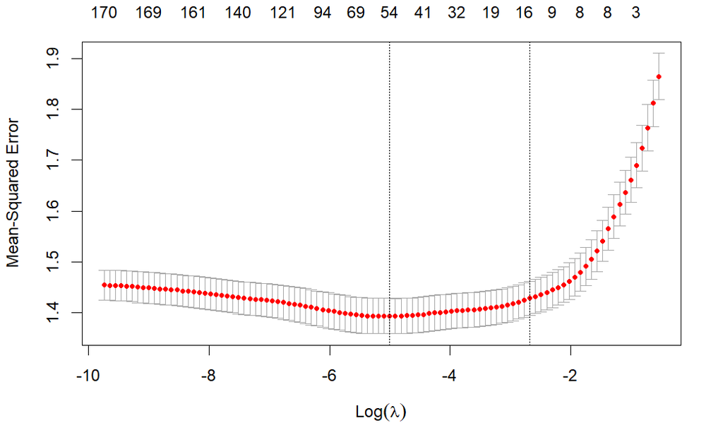

```r
plot(cv_f1)
```

```r
cv_f2 <- cv.glmnet(x = x, y = suppins, alpha  = 1, nfolds = 5, family = "binomial")
best_lambda_f2 <- cv_f2$lambda.min
best_lambda_f2
```

```
[1] 0.005063593
```

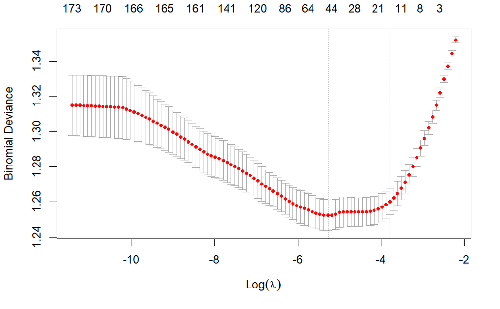

```r
plot(cv_f2)
```

```r
# Estimate LASSOs
lasso_f1 <- glmnet(x = x, y = ltotexp, alpha = 1, lambda = best_lambda_f1)
coef(lasso_f1)
```

```
174 x 1 sparse Matrix of class "dgCMatrix"
                           s0
(Intercept)      6.865127e+00
income           .
educyr           .
age              1.113448e-02
famsze          -3.575630e-02
totchr           5.235321e-01
female           .
white            .
hisp             .
marry            .
northe           .
mwest            .
south            .
msa              .
phylim           1.166590e-01
actlim           3.179895e-01
injury           .
priolist         .
hvgg             .
incomeXtotchr    1.496775e-02
incomeXwhite     .
incomeXmarry     .
incomeXnorthe    3.649018e-02
incomeXmwest    -4.018341e-02
incomeXsouth     .
incomeXmsa       .
incomeXphylim    .
incomeXinjury   -1.951467e-02
incomeXpriolist  .
educyrXincome    .
educyrXfamsze    .
educyrXtotchr    .
educyrXfemale   -4.525716e-02
educyrXwhite     .
educyrXhisp      .
educyrXmarry     6.471299e-02
educyrXnorthe    1.878655e-02
educyrXmwest     .
```

[output cut: 121 more lines]

```
hvggXtotchr     -7.947002e-03
hvggXwhite       .
hvggXmarry       1.428063e-02
hvggXnorthe      .
hvggXmwest       .
hvggXsouth       .
hvggXmsa         1.594840e-02
hvggXphylim     -4.408316e-02
hvggXinjury     -1.200017e-01
hvggXpriolist    .
incomeXincome   -2.273594e-02
educyrXeducyr    6.101080e-02
ageXage          .
famszeXfamsze    .
totchrXtotchr   -9.728163e-02
```

```r
lasso_f2 <- glmnet(x = x, y = suppins, alpha = 1, lambda = best_lambda_f2, family = "binomial")
coef(lasso_f2)
```

```
174 x 1 sparse Matrix of class "dgCMatrix"
                          s0
(Intercept)      0.450433006
income           0.117218204
educyr           0.142956154
age             -0.133172783
famsze           .
totchr           .
female           .
white            0.379927076
hisp             .
marry            .
northe           .
mwest            .
south            .
msa              .
phylim           .
actlim           .
injury           .
priolist         .
hvgg             .
incomeXtotchr    0.053590053
incomeXwhite     .
incomeXmarry     0.078500594
incomeXnorthe    .
incomeXmwest     0.060910981
incomeXsouth     0.112856705
incomeXmsa       0.095369552
incomeXphylim    0.053180311
incomeXinjury    0.024664002
incomeXpriolist  .
educyrXincome    .
educyrXfamsze    .
educyrXtotchr    .
educyrXfemale    .
educyrXwhite     0.050333810
educyrXhisp      .
educyrXmarry     0.105054256
educyrXnorthe    .
educyrXmwest     .
```

[output cut: 121 more lines]

```
hvggXtotchr      .
hvggXwhite       .
hvggXmarry       .
hvggXnorthe      0.186887966
hvggXmwest       .
hvggXsouth       .
hvggXmsa         .
hvggXphylim      0.260041368
hvggXinjury      .
hvggXpriolist    .
incomeXincome   -0.149007763
educyrXeducyr    .
ageXage          .
famszeXfamsze    0.073111914
totchrXtotchr    0.057730999
```

**f) Based on the residuals from the LASSO estiamtions, estimate α and its 95% confidence bounds.**

```r
# robust standard errors
# install.packages("sandwich")
# library(sandwich)

# predicted values from LASSO estimates
predicted_ltotexp <- predict(lasso_f1, newx = x)
residuals_ltotexp <- ltotexp - predicted_ltotexp

predicted_suppins <- predict(lasso_f2, newx = x, type = "class")
residuals_suppins <- suppins - as.double(predicted_suppins)

# OLS of residuals from ltotexp on residuals from suppins
alpha_lasso <- lm(residuals_ltotexp ~ 0 + residuals_suppins)


# robust variance-covariance matrix

calc_CI <- function(coef, Variance, n) {
        up_bound <- coef + 1.96 * sqrt(Variance/n)
        low_bound <- coef - 1.96 * sqrt(Variance/n)
        tibble(lower_bound = low_bound,
                upper_bound = up_bound)
}

V <- function(residuals_D, residuals_OLS, n) {
  (1 / ((n/(n-1)) * mean(residuals_D ^ 2))) * (n/(n-1)) * mean(residuals_OLS ^ 2 * residuals_D ^ 2) * (1 / ((n/(n-1)) * mean(residuals_D ^ 2)))
}

variance_lasso <- V(residuals_suppins, alpha_lasso$residuals, nrow(health_extend))

CI_lasso <- calc_CI(alpha_lasso$coefficients[["residuals_suppins"]], variance_lasso, nrow(health_extend))

alpha_lasso$coefficients[["residuals_suppins"]]
```

```
[1] 0.1356571
```

```r
CI_lasso
```

| lower_bound | upper_bound |
| --- | --- |
| 0.06172088 | 0.2095933 |

```r
NA
```

**g) Discuss similiarities and conceptual differences between choosing the optimal penalty parameter via cross-validation or information criteria.**

Both aim at finding the optimal penalty parameter, to minimize the test error.

Cross-Validation:

- directly estimates test error
- depends on splits

Information Criteria:

- indirectly estimates test error
- uses adjustments to the training error to account for bias due to overfitting

### Regression Tree

**h) Discuss, why using the extended variables set $x_{e,i}$ instead of using $x_{i}$ is superfluous(= redundant) according the fundamental concept of regression trees.**

Regression trees include interactions and polynomial terms by construction.

**i) When growing a decision tree, you have to decide about the desired level of complexity. Discuss, how the following hyper-parameters affect model complexity: • maximum depth of the tree • minimum number of observations in a leaf node • minimum improvement of performance induced by a split**

They all reduce the complexity of the tree:

- maximum depth: limits the tree size, seems somwhat arbitrary but can be optimized by using e.g. cross validation.
- minimum nr of obs in leaf node: Minimum number of observations that must be in each leaf, avoids overfitting.
- minimum improvement of performance induced by a split: compares performance of tree before a split and after a split and then only uses the split if the performance increases by some specified amount. Makes sense, but sometimes splits that dont lead to strong improvements lead to splits with strong improvements after.

**j) Estimate f1 and f2 by means of a regression tree. Use a maximum depth of 5 and make sure that in each leaf are at least 20 observations. Set the minimum improvement necessary for a further split to zero.**

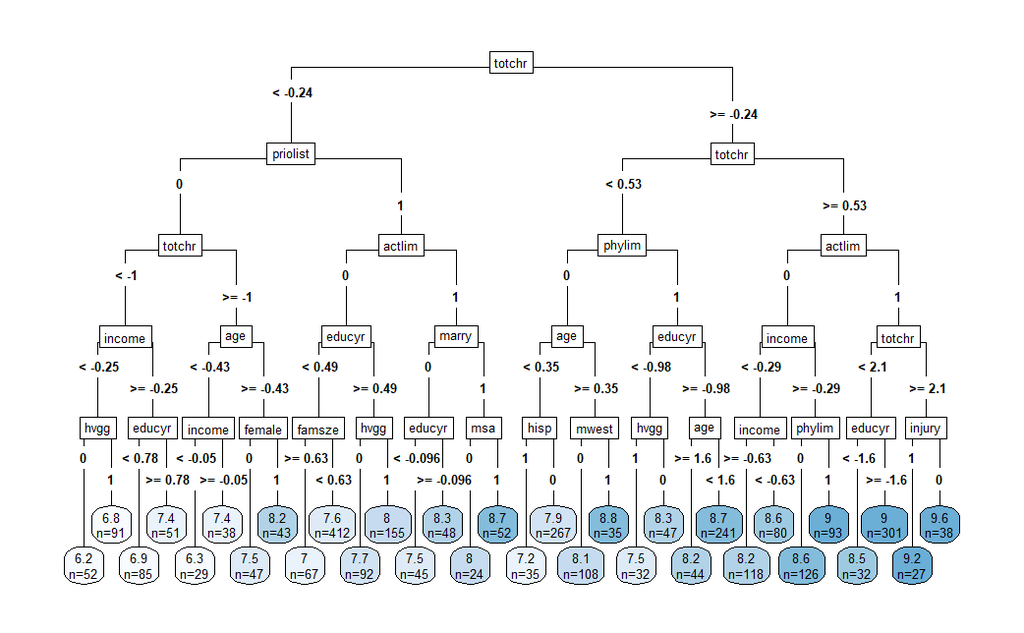

```r
tree_f1 <- rpart(ltotexp ~ . -suppins , data = health,
            minsplit = 0, minbucket = 20, maxdepth = 5, cp = 0.00, xval = 0)


tree_f2 <- rpart(suppins ~ . -ltotexp, data = health,
            minsplit = 0, minbucket = 20, maxdepth = 5, cp = 0.00, method = "class")


# plot f1
rpart.plot(tree_f1,
           tweak = 1,# we can tweak the size of the tree
           type = 5, # we can change the display of the decision nodes
           extra = 1) # we can change the display information of the terminal nodes
```

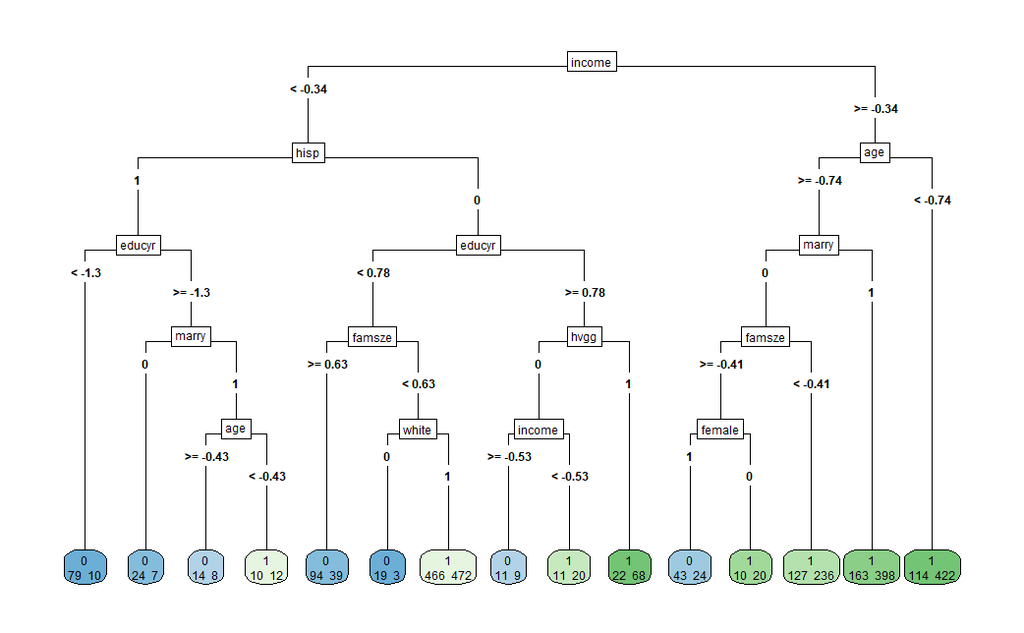

```r
rpart.plot(tree_f2,
           tweak = 1,# we can tweak the size of the tree
           type = 5, # we can change the display of the decision nodes
           extra = 1) # we can change the display information of the terminal nodes
```

**k) Briefly explain, why setting the minimum improvement for a split to zero still does not allow for infinite model complexity in this case.**

- Because we set the max depth to 5 and the minimum leaf size to 20 such that we cannot split w/o limit.

**l) Based on the residuals from the trees, estimate α and its 95% confidence bounds.**

```r
residuals_f1_tree <- residuals(tree_f1)
residuals_f2_tree <-  as.double(health$suppins) - as.double(predict(tree_f2, select(health, -suppins), type = "class"))

alpha_tree <- lm(residuals_f1_tree ~ 0 + residuals_f2_tree)

variance_tree <- V(residuals_f1_tree, alpha_tree$residuals, nrow(health))
CI_tree <- calc_CI(alpha_tree$coefficients[[1]], variance_tree, nrow(health))

alpha_tree$coefficients
```

```
residuals_f2_tree
        0.1026501
```

```r
CI_tree
```

| lower_bound | upper_bound |
| --- | --- |
| 0.03128284 | 0.1740174 |

### Conclusions

**m) Compare the estimates of α that you obtain via the partial linear model estimations (Lasso/tree) with the naive estimate from c).**

```r
stargazer(OLS, type = "text", keep = "suppins1", ci = TRUE,
          omit.stat = "all")
```

```
====================================
             Dependent variable:
         ---------------------------
                   ltotexp
------------------------------------
suppins1          0.171***
               (0.079, 0.262)

====================================
====================================
Note:    *p<0.1; **p<0.05; ***p<0.01
```

```r
alpha_lasso
```

```
Call:
lm(formula = residuals_ltotexp ~ 0 + residuals_suppins)

Coefficients:
residuals_suppins
           0.1357
```

```r
CI_lasso
```

| lower_bound | upper_bound |
| --- | --- |
| 0.06172088 | 0.2095933 |

```r
alpha_tree
```

```
Call:
lm(formula = residuals_f1_tree ~ 0 + residuals_f2_tree)

Coefficients:
residuals_f2_tree
           0.1027
```

```r
CI_tree
```

| lower_bound | upper_bound |
| --- | --- |
| 0.03128284 | 0.1740174 |

All coefficients are of the same order if magnitude, yet the OLS coefficient is largest, followed by the double LASSO and the double tree coefficients.

**n) Check, whether the confidence bounds of the three estimates of α are overlapping. Discuss your results. What is the value-added by estimating the partial linear model via LASSO/tree?** Yes, the confidence bounds are overlapping. Therefore, including interaction terms and polynomials and estimating the effect using double LASSO or double trees does not yield a statistically different result than the a naive OLS without interaction terms or polynomials. The value-added of estimating a partial linear model lies in reduced noise when estimating a high-dimensional regression. Below we can see that in a naive OLS with the extended set of regressors, the confidence interval is slightly wider than in the double ML regressions.

```r
OLS_high <- lm(ltotexp ~ ., data = health_extend)
stargazer(OLS_high, type = "text", keep = "suppins1", ci = TRUE,
          omit.stat = "all")
```

```
====================================
             Dependent variable:
         ---------------------------
                   ltotexp
------------------------------------
suppins1          0.187***
               (0.093, 0.281)

====================================
====================================
Note:    *p<0.1; **p<0.05; ***p<0.01
```

**o) Discuss disadvantages of the partial linear model approach with respect to the treatment effect compared to e.g. propensity score weighting.**

- The partial linear model assumes that the effect of the treatment on the outcome is additive (and linear). These assumptions are not necessary for propensity score weighting.
- Overfitting and regularization can lead to biased estimates, however this can be mitigated by cross fitting and orthogonalization.